# IODS course project

Anniina Kotkaniemi

# Introduction to Open Data Science - Course Project

# Chapter 1

*Course diary for the Introduction to Open Data Science Course. Link to the project GitHub Repository: https://github.com/anniinakotkaniemi/IODS-project*

```r
# This is a so-called "R chunk" where you can write R code.

hello <- "Hello reviewer!"

date()
```

```
## [1] "Mon Dec 11 21:54:03 2023"
```

```r
print(hello)
```

```
## [1] "Hello reviewer!"
```

*Do I just write text here then? I’m still so confused with the R Markdown files.*

My first impressions of working with the tools of this course

I am feeling a bit lost to be honest. I have been working with RStudio for a couple of years now, mostly with the good old learning by doing (and Googling) method. Still, this is all very new to me.

All the new additions (Git, RMarkdown, working with this IODS project on RStudio and the magic how this file then is going to find its way in the course diary) make me feel like someone would have come to my house and completely arbitrary changed the place of ALL my stuff. Like, I know that it is my stuff and I am familiar with it, but I can not find anything and how everything is arranged lacks all logic (to me).

But, I am expecting to learn more about all these confusing new things, and I am very excited about it! (Although right now I’m struggling with a few deadlines, but I’ll have more time to focus on learning in a week or so.) I hope to get a good crash-course on Git and learn how to use GitHub more fluently when working with code.

I heard from the course from our very own Kimmo, I’m happy to have worked with him earlier and glad that he suggested I take social sciences statistics (and data science) courses when starting off with my PhD studies. **Thanks Kimmo!**

Reflecting about my experiences with the R for Health Data Science book and the Exercise Set 1:

As someone who has already used RStudio and the basic tools such as ggplot, it was a good recap and a demonstration on all the nice visualizations that are available. I have actually not worked with the %>%-command from tidyverse before, even though I’ve seen it used. I have found it a bit “scary” as it deviates from what I’m used to, so it was very good to see so many examples using it. I will definitely start using it more in the future, as it is much more elegant for many functions that I’ve done with basic R before (such as the subset() function for subsetting instead of just filtering as you do with the %>%). As I did not have that much time for conducting the exercises, I found it a bit hard when you had to make your own ggplots. But I’m happy to come back to the exercises next time I’m doing visualizations, as they give good hands-on examples for doing plots and graphs!

# Chapter 2 Regression and model validation

```r
date()
```

```
## [1] "Mon Dec 11 21:54:03 2023"
```

```r
learning2014 <- read.table("https://raw.githubusercontent.com/KimmoVehkalahti/Helsinki-Open-Data-Science/master/datasets/learning2014.txt", sep=",", header=T)

# Explore the structure and dimensions of the data
str(learning2014)
```

```
## 'data.frame':    166 obs. of  7 variables:
##  $ gender  : chr  "F" "M" "F" "M" ...
##  $ age     : int  53 55 49 53 49 38 50 37 37 42 ...
##  $ attitude: num  3.7 3.1 2.5 3.5 3.7 3.8 3.5 2.9 3.8 2.1 ...
##  $ deep    : num  3.58 2.92 3.5 3.5 3.67 ...
##  $ stra    : num  3.38 2.75 3.62 3.12 3.62 ...
##  $ surf    : num  2.58 3.17 2.25 2.25 2.83 ...
##  $ points  : int  25 12 24 10 22 21 21 31 24 26 ...
```

```r
dim(learning2014)
```

```
## [1] 166   7
```

The examination shows that it is a datadrame object with 166 observations that take 7 variables: gender, age, attitude, deep, stra, surf and points

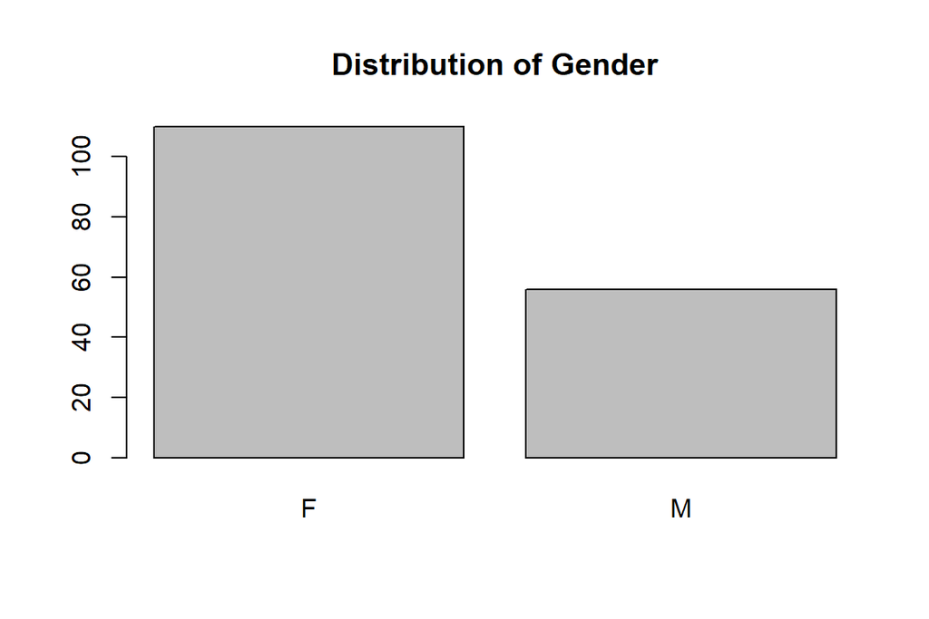

```r
# Graphical overview of data
table_gender <- table(learning2014$gender)
barplot(table_gender, main="Distribution of Gender")
```

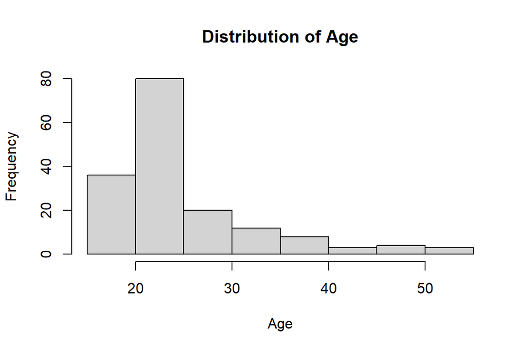

```r
hist(learning2014$age, main="Distribution of Age", xlab="Age")
```

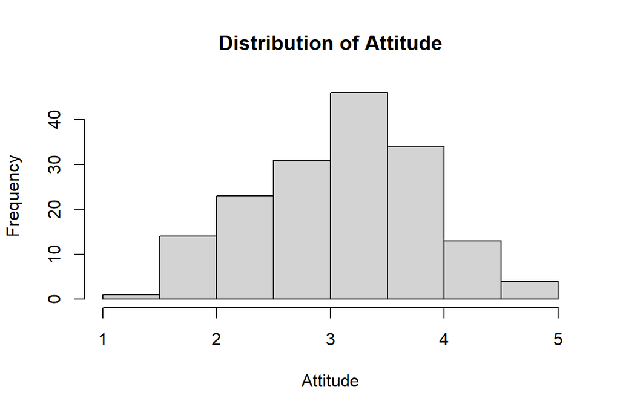

```r
hist(learning2014$attitude, main="Distribution of Attitude", xlab="Attitude")
```

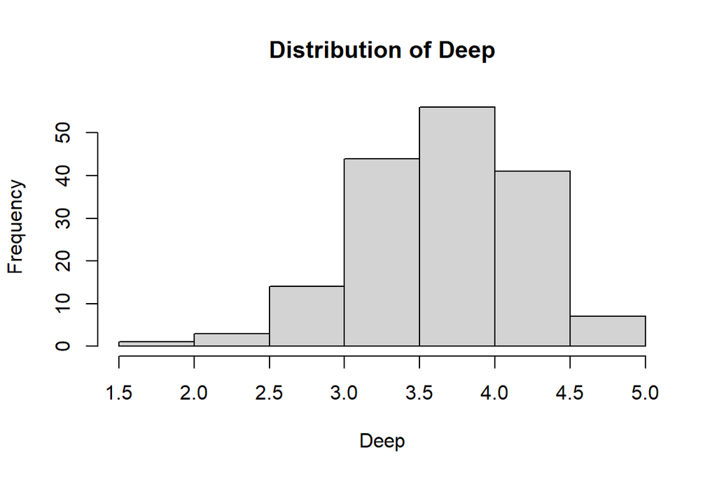

```r
hist(learning2014$deep, main="Distribution of Deep", xlab="Deep")
```

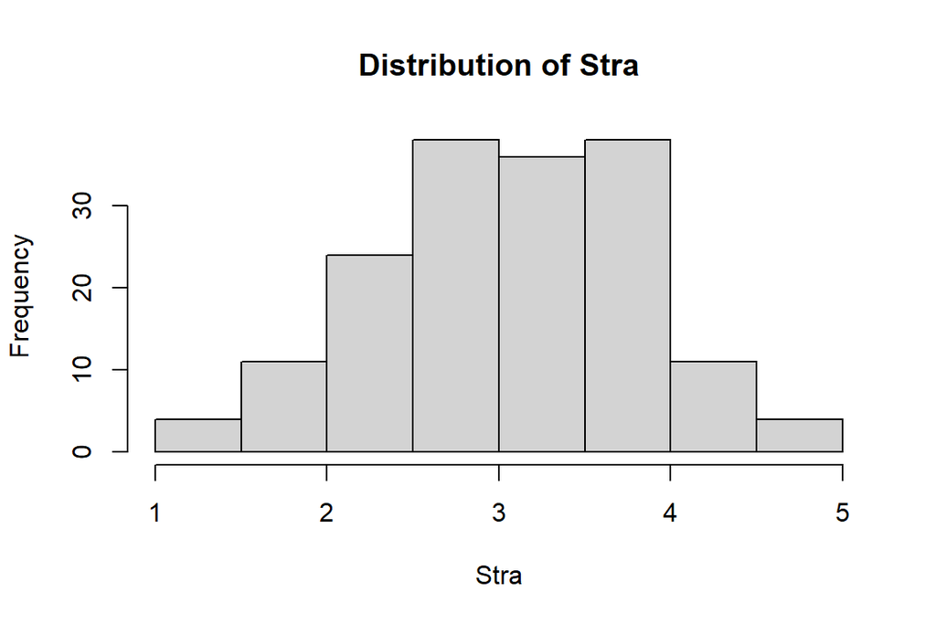

```r
hist(learning2014$stra, main="Distribution of Stra", xlab="Stra")
```

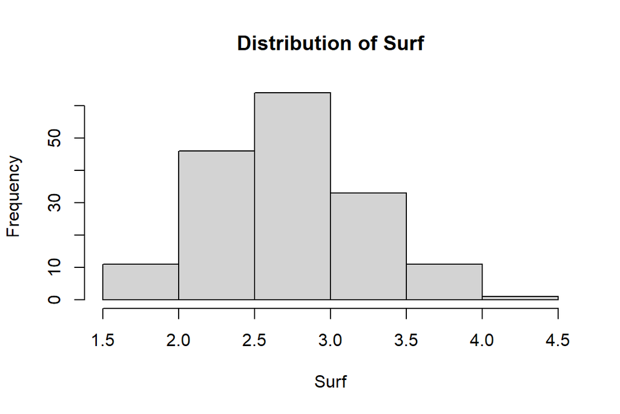

```r
hist(learning2014$surf, main="Distribution of Surf", xlab="Surf")
```

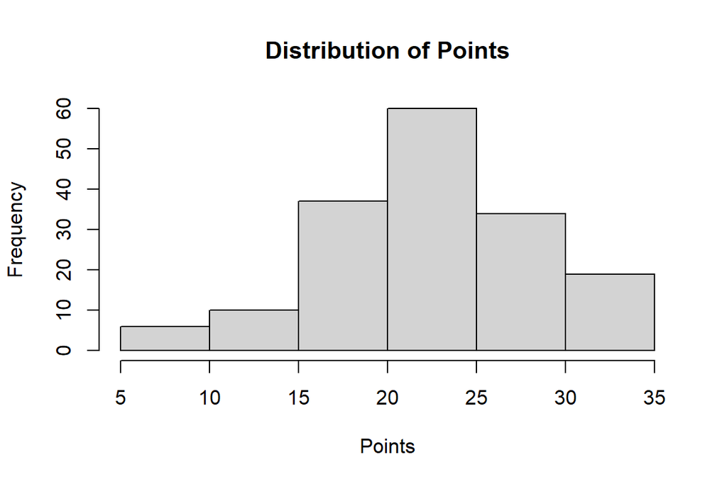

```r
hist(learning2014$points, main="Distribution of Points", xlab="Points")
```

```r
# Summaries of the data
table(learning2014$gender)
```

```
##
##   F   M
## 110  56
```

```r
summary(learning2014$attitude)
```

```
##    Min. 1st Qu.  Median    Mean 3rd Qu.    Max.
##   1.400   2.600   3.200   3.143   3.700   5.000
```

```r
summary(learning2014$age)
```

```
##    Min. 1st Qu.  Median    Mean 3rd Qu.    Max.
##   17.00   21.00   22.00   25.51   27.00   55.00
```

```r
summary(learning2014$deep)
```

```
##    Min. 1st Qu.  Median    Mean 3rd Qu.    Max.
##   1.583   3.333   3.667   3.680   4.083   4.917
```

```r
summary(learning2014$stra)
```

```
##    Min. 1st Qu.  Median    Mean 3rd Qu.    Max.
##   1.250   2.625   3.188   3.121   3.625   5.000
```

```r
summary(learning2014$surf)
```

```
##    Min. 1st Qu.  Median    Mean 3rd Qu.    Max.
##   1.583   2.417   2.833   2.787   3.167   4.333
```

```r
summary(learning2014$points)
```

```
##    Min. 1st Qu.  Median    Mean 3rd Qu.    Max.
##    7.00   19.00   23.00   22.72   27.75   33.00
```

The graphical overview and the summaries show firstly that there is almost twice as many female (110) than there are men (56) in the data. The age distribution shows that there are most respondents that are 20 to 25 years old, but that the median is 22 and the mean is 25 and half years. The age span of the respondents is from 17 to 55 years. The rest of the variables show, as could be expected, a distribution close to a normal distribution. This is the case especially for the Distribution of Points, whereas distributions for Deep and Surf are both sligthly tilted. Comparing median and mean values for the variables shows however that the values are rather equally divided in the data, as the two values are rather close to each other.

```r
# Fitting the regression model with Exam points as the dependent variable and gender, attitude and age as independent variables

model.1 <- lm(points ~ gender + attitude + age, data = learning2014)

# Summarize the model
summary(model.1)
```

```
##
## Call:
## lm(formula = points ~ gender + attitude + age, data = learning2014)
##
## Residuals:
##      Min       1Q   Median       3Q      Max
## -17.4590  -3.3221   0.2186   4.0247  10.4632
##
## Coefficients:
##             Estimate Std. Error t value Pr(>|t|)
## (Intercept) 13.42910    2.29043   5.863 2.48e-08 ***
## genderM     -0.33054    0.91934  -0.360    0.720
## attitude     3.60657    0.59322   6.080 8.34e-09 ***
## age         -0.07586    0.05367  -1.414    0.159
## ---
## Signif. codes:  0 '***' 0.001 '**' 0.01 '*' 0.05 '.' 0.1 ' ' 1
##
## Residual standard error: 5.315 on 162 degrees of freedom
## Multiple R-squared:  0.2018, Adjusted R-squared:  0.187
## F-statistic: 13.65 on 3 and 162 DF,  p-value: 5.536e-08
```

The regression model shows that in the multivariate regression model with gender, attitude and age as explanatory variables, only attitude gives a positive and statistically significant effect to higher exam results. With one units increase in attitude, the exam results are expected to rise by 3.6. Thus, when the gender and age or respondents are hold constant, having a good attitude towards the course is associated with also faring better with the course.

As the model contains two variables, gender and age, that show no statistically significant relationship with the outcome variable, I test to fit the model without them.

```r
# Model 2 without age
model.2 <- lm(points ~ gender + attitude, data = learning2014)
# Summarize the model
summary(model.2)
```

```
##
## Call:
## lm(formula = points ~ gender + attitude, data = learning2014)
##
## Residuals:
##      Min       1Q   Median       3Q      Max
## -17.1724  -3.2092   0.3703   4.0197  10.6162
##
## Coefficients:
##             Estimate Std. Error t value Pr(>|t|)
## (Intercept)  11.5098     1.8502   6.221 4.01e-09 ***
## genderM      -0.4835     0.9157  -0.528    0.598
## attitude      3.6179     0.5950   6.081 8.21e-09 ***
## ---
## Signif. codes:  0 '***' 0.001 '**' 0.01 '*' 0.05 '.' 0.1 ' ' 1
##
## Residual standard error: 5.331 on 163 degrees of freedom
## Multiple R-squared:  0.1919, Adjusted R-squared:  0.182
## F-statistic: 19.36 on 2 and 163 DF,  p-value: 2.863e-08
```

```r
# Model 3 without attitude
model.3 <- lm(points ~ attitude + age, data = learning2014)
# Summarize the model
summary(model.3)
```

```
##
## Call:
## lm(formula = points ~ attitude + age, data = learning2014)
##
## Residuals:
##      Min       1Q   Median       3Q      Max
## -17.3354  -3.3095   0.2625   4.0005  10.4911
##
## Coefficients:
##             Estimate Std. Error t value Pr(>|t|)
## (Intercept) 13.57244    2.24943   6.034 1.04e-08 ***
## attitude     3.54392    0.56553   6.267 3.17e-09 ***
## age         -0.07813    0.05315  -1.470    0.144
## ---
## Signif. codes:  0 '***' 0.001 '**' 0.01 '*' 0.05 '.' 0.1 ' ' 1
##
## Residual standard error: 5.301 on 163 degrees of freedom
## Multiple R-squared:  0.2011, Adjusted R-squared:  0.1913
## F-statistic: 20.52 on 2 and 163 DF,  p-value: 1.125e-08
```

```r
# Model 4 without both gender and age
model.4 <- lm(points ~ attitude, data = learning2014)
# Summarize the model
summary(model.4)
```

```
##
## Call:
## lm(formula = points ~ attitude, data = learning2014)
##
## Residuals:
##      Min       1Q   Median       3Q      Max
## -16.9763  -3.2119   0.4339   4.1534  10.6645
##
## Coefficients:
##             Estimate Std. Error t value Pr(>|t|)
## (Intercept)  11.6372     1.8303   6.358 1.95e-09 ***
## attitude      3.5255     0.5674   6.214 4.12e-09 ***
## ---
## Signif. codes:  0 '***' 0.001 '**' 0.01 '*' 0.05 '.' 0.1 ' ' 1
##
## Residual standard error: 5.32 on 164 degrees of freedom
## Multiple R-squared:  0.1906, Adjusted R-squared:  0.1856
## F-statistic: 38.61 on 1 and 164 DF,  p-value: 4.119e-09
```

Omitting age and gender does not give much new information as opposed to the full multivariate model.

Based on the fitted model, a positive attitude is positively correlated with exam results. Age and gender, on the contrary, show no statistically significant effect. As gender is binary variable, the coefficient “genderM” shows the effect of being a male, or “going from female to male”. The coefficients of age and gender are although negative, leaving room for speculation whether there could be found a negative relationship between these variables and the outcome variable. That could mean that being older leads to lower exam results, and that women fare better than men in the exam. This is however mostly speculative, as these relationships could not be statistically confirmed even on 0.1 alpha value level.

Even though attitude shows a strong effect on the target variable, both the multiple and adjusted R-squared values shows that this model only succeeds to explain roughly 20 per cent of the variation in the outcome variable; thus, the model is likely omit many variables that are highly linked with exam performance. Such variables could be for example interest in the course topic and previous performance in exams.

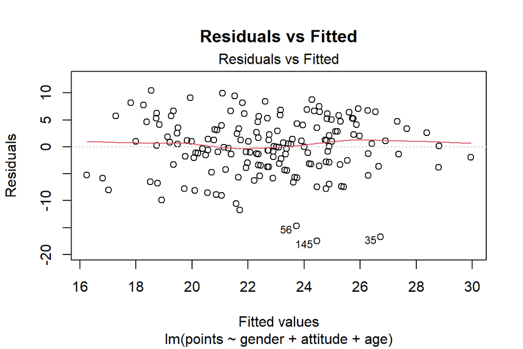

```r
#  Residuals vs Fitted values plot
plot(model.1, which = 1, main = "Residuals vs Fitted")
```

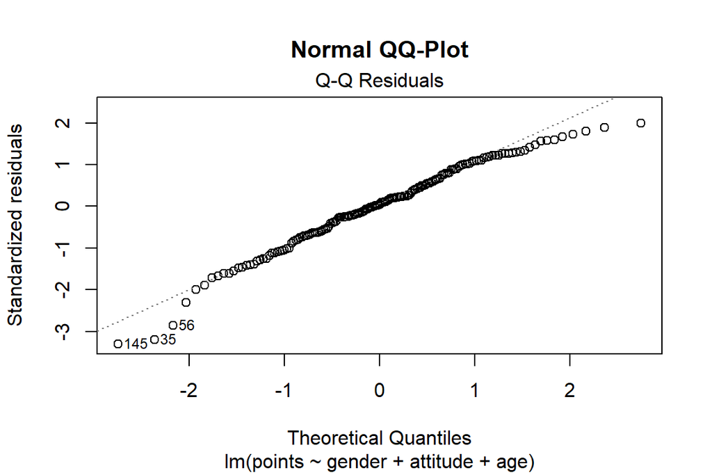

```r
# Normal QQ-plot
plot(model.1, which = 2, main = "Normal QQ-Plot")
```

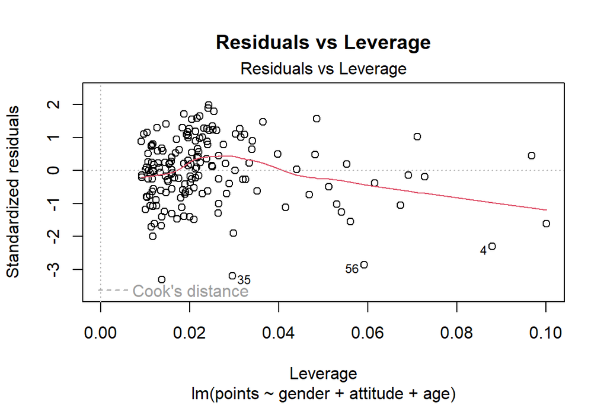

```r
# Residuals vs Leverage plot
plot(model.1, which = 5, main = "Residuals vs Leverage")
```

Firstly, the residuals vs fitted values plot shows that the residuals are rather randomly scattered around the horizontal axis. This is good news to the explanatory power of our model as it indicates that no serious concerns of heteroscedasticity or non-linearity are apparent in the data.

In the Normal QQ plot, points should approximately follow a straight line. Departures from linearity may suggest deviations from normality in the residuals. This expectation is mostly fulfilled: the plots follow the straight line for the most of it, deviating only in the beginning and in the end.

The residuals vs leverage plot helps identifying influential observations with high leverage. Points outside the Cook’s distance lines may have a disproportionate influence on the regression coefficients. It would seem to indicate that there are no observations that would have substantial impact on the regression coefficients.

# Chapter 3 Logistic Regression

```r
date()
```

```
## [1] "Mon Dec 11 21:54:07 2023"
```

```r
# 2
# Read the alc dataframe
# First making sure that my dataframe is equal to Kimmo's
alc <- read.table("https://raw.githubusercontent.com/KimmoVehkalahti/Helsinki-Open-Data-Science/master/datasets/alc.csv", sep=",", header=T)
alc_mine <- read.csv("~/IODS-project/data/alc.csv")
# Compare data frames using all.equal
all.equal(alc, alc_mine)
```

```
## [1] TRUE
```

```r
# All good!

# Print the names of variables
names(alc)
```

```
##  [1] "school"     "sex"        "age"        "address"    "famsize"
##  [6] "Pstatus"    "Medu"       "Fedu"       "Mjob"       "Fjob"
## [11] "reason"     "guardian"   "traveltime" "studytime"  "schoolsup"
## [16] "famsup"     "activities" "nursery"    "higher"     "internet"
## [21] "romantic"   "famrel"     "freetime"   "goout"      "Dalc"
## [26] "Walc"       "health"     "failures"   "paid"       "absences"
## [31] "G1"         "G2"         "G3"         "alc_use"    "high_use"
```

The dataframe includes information about student achievement in education of two Portugese schools. Attributes include grades, demographic, social and school related features.

3. Studying the relationships between high/low alcohol consumption and some other variables. I study 4 focus variables: sex, age, absences and higher

My hypotheses for the study:

H1: Gender is likely to affect alcohol consumption; being a man is positively related with higher alcohol consumption H2: Older students drink more; Age is positively related with higher alcohol consumption H3: Having many absences is positively related to higher alcohol consumption H4: Wanting to take higher education is negatively related to higher alcohol consumption

*Next, moving on to exploring the data!*

```r
# Exploring the distributions of variables
# Age and absences
summary(alc[c('age', 'absences')])
```

```
##       age           absences
##  Min.   :15.00   Min.   : 0.000
##  1st Qu.:16.00   1st Qu.: 1.000
##  Median :17.00   Median : 3.000
##  Mean   :16.58   Mean   : 4.511
##  3rd Qu.:17.00   3rd Qu.: 6.000
##  Max.   :22.00   Max.   :45.000
```

```r
# Sex
table(alc$sex)
```

```
##
##   F   M
## 195 175
```

```r
# Higher
table(alc$higher)
```

```
##
##  no yes
##  16 354
```

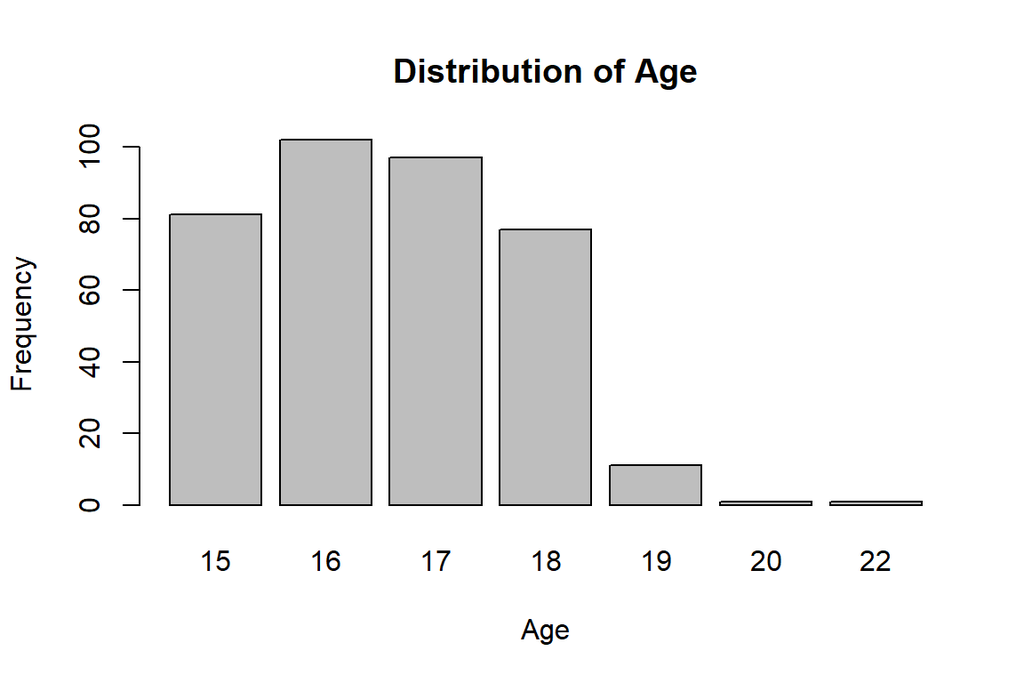

```r
# Barplots
barplot(table(alc$age), main = "Distribution of Age", xlab='Age', ylab='Frequency')
```

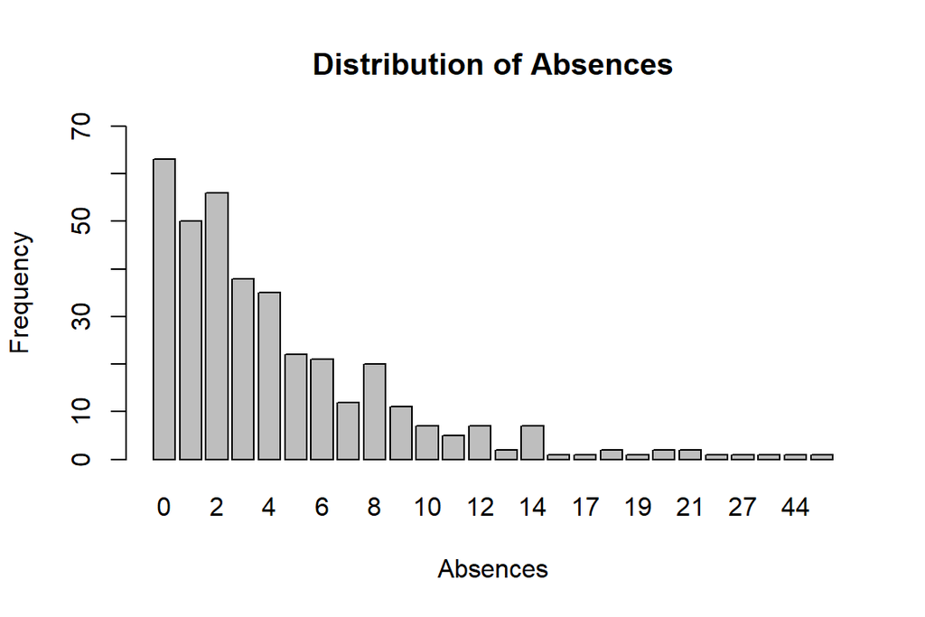

```r
barplot(table(alc$absences), main = "Distribution of Absences", xlab='Absences', ylab='Frequency', ylim=c(0,70))
```

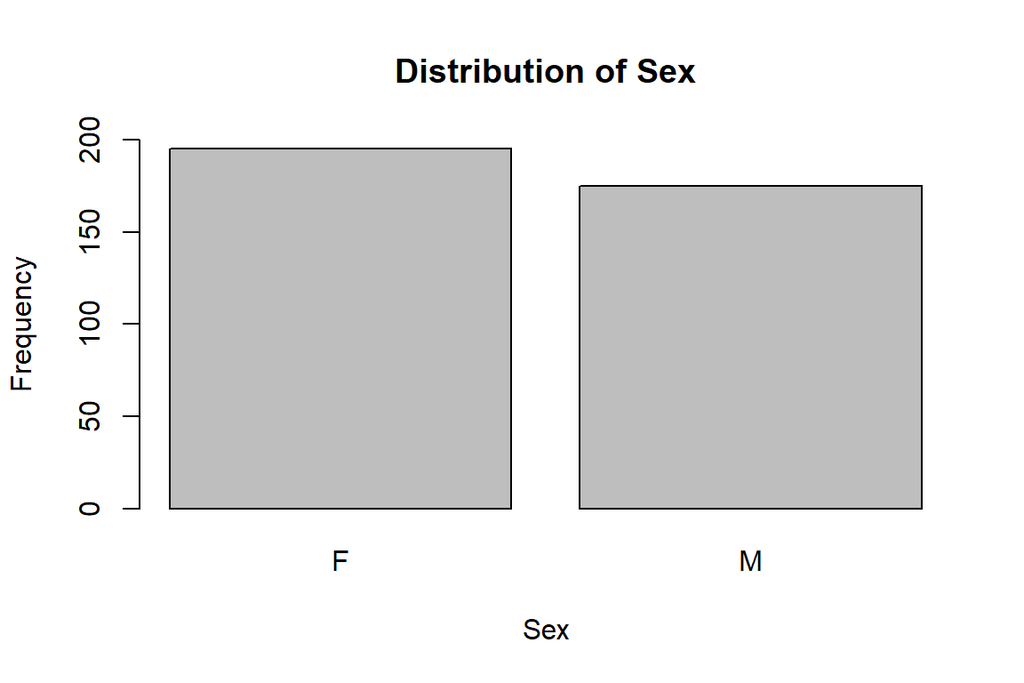

```r
barplot(table(alc$sex), main = "Distribution of Sex", xlab='Sex', ylab='Frequency', ylim=c(0,200))
```

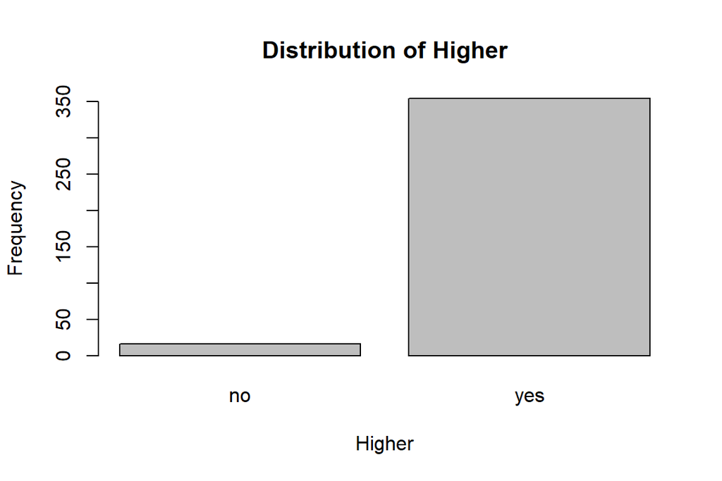

```r
barplot(table(alc$higher), main = "Distribution of Higher", xlab='Higher', ylab='Frequency')
```

The data shows that the students are between 15 and 22 years old, and majority of them have no or only a few absences. However, there are a few outliers with over 10 or as many as 45 absences. There are approximately as many female (195) as men (175), however, only a small group does not want to continue to higher education (16 said no) whereas as many as 354 said yes in the survey.

Regarding my hypothesis, this exploration tells me that the variable ‘higher’ is not likely to show an effect due to so few in the ‘no’ category, but as for the other variables, they might show effects in the modeling. Especially absences I would expect to give an effect, as there are quite many still with over 10 absences.

*Next up, modeling the data with logistic regression!*

```r
# 5
# Convert 'sex' and 'higher' to factors
alc$sex <- as.factor(alc$sex)
alc$higher <- as.factor(alc$higher)

# Fit logistic regression model
log_model <- glm(alc_use ~ age + sex + absences + higher, data = alc)
# The summary of the model
summary(log_model)
```

```
##
## Call:
## glm(formula = alc_use ~ age + sex + absences + higher, data = alc)
##
## Coefficients:
##             Estimate Std. Error t value Pr(>|t|)
## (Intercept) -0.28591    0.79611  -0.359  0.71970
## age          0.11065    0.04226   2.618  0.00921 **
## sexM         0.59330    0.09741   6.091 2.85e-09 ***
## absences     0.03837    0.00883   4.346 1.80e-05 ***
## higheryes   -0.11776    0.24664  -0.477  0.63333
## ---
## Signif. codes:  0 '***' 0.001 '**' 0.01 '*' 0.05 '.' 0.1 ' ' 1
##
## (Dispersion parameter for gaussian family taken to be 0.8512614)
##
##     Null deviance: 367.46  on 369  degrees of freedom
## Residual deviance: 310.71  on 365  degrees of freedom
## AIC: 997.4
##
## Number of Fisher Scoring iterations: 2
```

```r
# Looking at odds ratios
exp(coef(log_model))
```

```
## (Intercept)         age        sexM    absences   higheryes
##   0.7513288   1.1170023   1.8099430   1.0391158   0.8889098
```

```r
# Provide confidence intervals for the odds ratios
exp(confint(log_model))
```

```
##                 2.5 %   97.5 %
## (Intercept) 0.1578259 3.576694
## age         1.0282022 1.213472
## sexM        1.4953685 2.190693
## absences    1.0212876 1.057255
## higheryes   0.5481702 1.441451
```

As posited, the higher variable did not give an effect. The confidence interval comprises 1, and also in the regression output it can be read that the term is statistically non-significant. Thus, the ambition to continue to higher education did not show a relationship to alcohol consumption with this data. However, this could also be due to the vast majority of the respondents wanting to continue their education; different results could be obtained with data where there was more distribution in this variable.

*Almost there, continuing to exploring the predictive power of my model!*

```r
# Make predictions
predictions <- predict(log_model, type = "response") > 0.5
# Create a 2x2 cross-tabulation
confusion_matrix <- table(Actual = alc$alc_use, Predicted = predictions)
print(confusion_matrix)
```

```
##       Predicted
## Actual TRUE
##    1    140
##    1.5   63
##    2     56
##    2.5   41
##    3     32
##    3.5   17
##    4      9
##    4.5    3
##    5      9
```

```r
# Did not have time to solve this last one before the deadline (why does everything always have to be done in the last minute :) )
```

# Chapter 4 Clustering and classification

```r
# load the Boston data
library(MASS)
data("Boston")
dim(Boston)
```

```
## [1] 506  14
```

```r
str(Boston)
```

```
## 'data.frame':    506 obs. of  14 variables:
##  $ crim   : num  0.00632 0.02731 0.02729 0.03237 0.06905 ...
##  $ zn     : num  18 0 0 0 0 0 12.5 12.5 12.5 12.5 ...
##  $ indus  : num  2.31 7.07 7.07 2.18 2.18 2.18 7.87 7.87 7.87 7.87 ...
##  $ chas   : int  0 0 0 0 0 0 0 0 0 0 ...
##  $ nox    : num  0.538 0.469 0.469 0.458 0.458 0.458 0.524 0.524 0.524 0.524 ...
##  $ rm     : num  6.58 6.42 7.18 7 7.15 ...
##  $ age    : num  65.2 78.9 61.1 45.8 54.2 58.7 66.6 96.1 100 85.9 ...
##  $ dis    : num  4.09 4.97 4.97 6.06 6.06 ...
##  $ rad    : int  1 2 2 3 3 3 5 5 5 5 ...
##  $ tax    : num  296 242 242 222 222 222 311 311 311 311 ...
##  $ ptratio: num  15.3 17.8 17.8 18.7 18.7 18.7 15.2 15.2 15.2 15.2 ...
##  $ black  : num  397 397 393 395 397 ...
##  $ lstat  : num  4.98 9.14 4.03 2.94 5.33 ...
##  $ medv   : num  24 21.6 34.7 33.4 36.2 28.7 22.9 27.1 16.5 18.9 ...
```

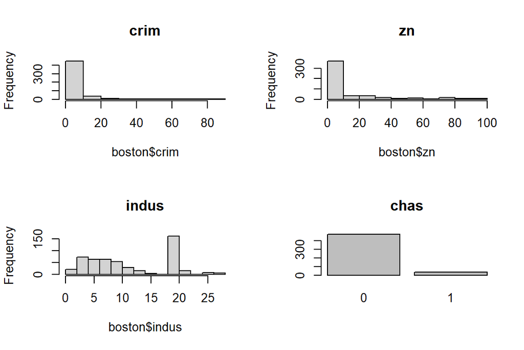

```r
# Simplifying the name of the dataframe
boston <- Boston

# Graphical overview of the data
par(mfrow = c(2,2))
hist(boston$crim, main = "crim")
hist(boston$zn,  main = "zn")
hist(boston$indus, main = "indus")
barplot(table(boston$chas), main = 'chas')
```

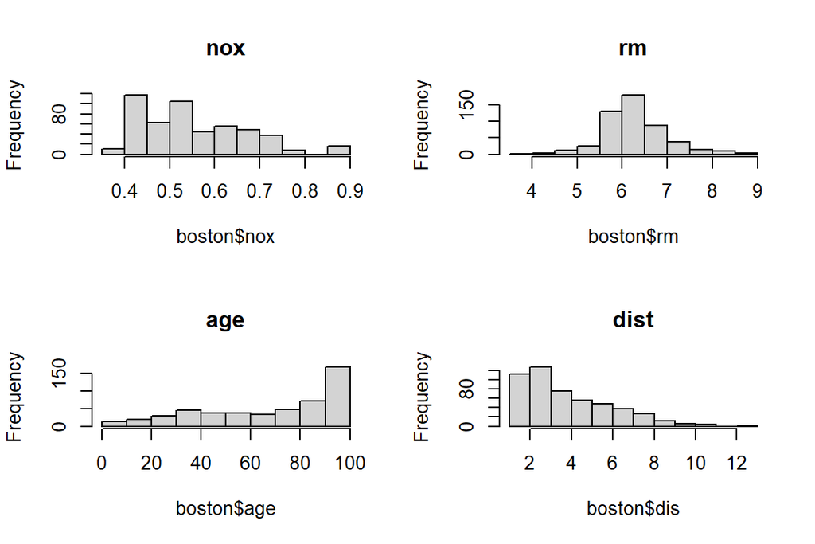

```r
hist(boston$nox, main = "nox")
hist(boston$rm, main = "rm")
hist(boston$age, main = "age")
hist(boston$dis, main = "dist")
```

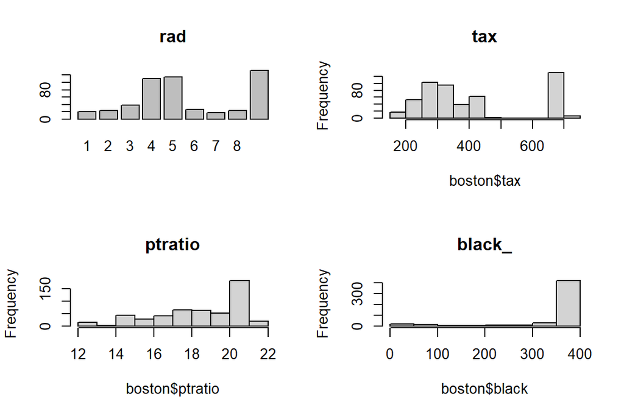

```r
barplot(table(boston$rad), main = 'rad')
hist(boston$tax, main = "tax")
hist(boston$ptratio, main = "ptratio")
hist(boston$black, main = "black_")
```

```r
hist(boston$lstat, main = "lstat")
hist(boston$medv, main = "medv")

# Summaries of the data
summary(boston)
```

```
##       crim                zn             indus            chas
##  Min.   : 0.00632   Min.   :  0.00   Min.   : 0.46   Min.   :0.00000
##  1st Qu.: 0.08205   1st Qu.:  0.00   1st Qu.: 5.19   1st Qu.:0.00000
##  Median : 0.25651   Median :  0.00   Median : 9.69   Median :0.00000
##  Mean   : 3.61352   Mean   : 11.36   Mean   :11.14   Mean   :0.06917
##  3rd Qu.: 3.67708   3rd Qu.: 12.50   3rd Qu.:18.10   3rd Qu.:0.00000
##  Max.   :88.97620   Max.   :100.00   Max.   :27.74   Max.   :1.00000
##       nox               rm             age              dis
##  Min.   :0.3850   Min.   :3.561   Min.   :  2.90   Min.   : 1.130
##  1st Qu.:0.4490   1st Qu.:5.886   1st Qu.: 45.02   1st Qu.: 2.100
##  Median :0.5380   Median :6.208   Median : 77.50   Median : 3.207
##  Mean   :0.5547   Mean   :6.285   Mean   : 68.57   Mean   : 3.795
##  3rd Qu.:0.6240   3rd Qu.:6.623   3rd Qu.: 94.08   3rd Qu.: 5.188
##  Max.   :0.8710   Max.   :8.780   Max.   :100.00   Max.   :12.127
##       rad              tax           ptratio          black
##  Min.   : 1.000   Min.   :187.0   Min.   :12.60   Min.   :  0.32
##  1st Qu.: 4.000   1st Qu.:279.0   1st Qu.:17.40   1st Qu.:375.38
##  Median : 5.000   Median :330.0   Median :19.05   Median :391.44
##  Mean   : 9.549   Mean   :408.2   Mean   :18.46   Mean   :356.67
##  3rd Qu.:24.000   3rd Qu.:666.0   3rd Qu.:20.20   3rd Qu.:396.23
##  Max.   :24.000   Max.   :711.0   Max.   :22.00   Max.   :396.90
##      lstat            medv
##  Min.   : 1.73   Min.   : 5.00
##  1st Qu.: 6.95   1st Qu.:17.02
##  Median :11.36   Median :21.20
##  Mean   :12.65   Mean   :22.53
##  3rd Qu.:16.95   3rd Qu.:25.00
##  Max.   :37.97   Max.   :50.00
```

```r
# Looking at the distribution of the binary variable chas
table(boston$chas)
```

```
##
##   0   1
## 471  35
```

[figure not shown]

Let’s move on to examining the correlations between the variables:

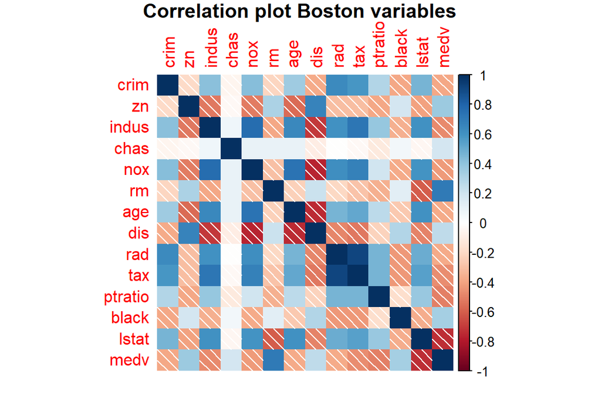

```r
# create the correlation matrix, round it to two digits
cor_matrix <- round(cor(boston),2)
# This does not tell us much yet - let's visualize it
library(corrplot)
corrplot(cor_matrix, method="shade", title = "Correlation plot Boston variables", mar=c(1,1,1,1))
```

Off to standardizing the dataset!

```r
# Scale the Boston data set
boston_scaled <- scale(boston)
summary(boston_scaled)
```

```
##       crim                 zn               indus              chas
##  Min.   :-0.419367   Min.   :-0.48724   Min.   :-1.5563   Min.   :-0.2723
##  1st Qu.:-0.410563   1st Qu.:-0.48724   1st Qu.:-0.8668   1st Qu.:-0.2723
##  Median :-0.390280   Median :-0.48724   Median :-0.2109   Median :-0.2723
##  Mean   : 0.000000   Mean   : 0.00000   Mean   : 0.0000   Mean   : 0.0000
##  3rd Qu.: 0.007389   3rd Qu.: 0.04872   3rd Qu.: 1.0150   3rd Qu.:-0.2723
##  Max.   : 9.924110   Max.   : 3.80047   Max.   : 2.4202   Max.   : 3.6648
##       nox                rm               age               dis
##  Min.   :-1.4644   Min.   :-3.8764   Min.   :-2.3331   Min.   :-1.2658
##  1st Qu.:-0.9121   1st Qu.:-0.5681   1st Qu.:-0.8366   1st Qu.:-0.8049
##  Median :-0.1441   Median :-0.1084   Median : 0.3171   Median :-0.2790
##  Mean   : 0.0000   Mean   : 0.0000   Mean   : 0.0000   Mean   : 0.0000
##  3rd Qu.: 0.5981   3rd Qu.: 0.4823   3rd Qu.: 0.9059   3rd Qu.: 0.6617
##  Max.   : 2.7296   Max.   : 3.5515   Max.   : 1.1164   Max.   : 3.9566
##       rad               tax             ptratio            black
##  Min.   :-0.9819   Min.   :-1.3127   Min.   :-2.7047   Min.   :-3.9033
##  1st Qu.:-0.6373   1st Qu.:-0.7668   1st Qu.:-0.4876   1st Qu.: 0.2049
##  Median :-0.5225   Median :-0.4642   Median : 0.2746   Median : 0.3808
##  Mean   : 0.0000   Mean   : 0.0000   Mean   : 0.0000   Mean   : 0.0000
##  3rd Qu.: 1.6596   3rd Qu.: 1.5294   3rd Qu.: 0.8058   3rd Qu.: 0.4332
##  Max.   : 1.6596   Max.   : 1.7964   Max.   : 1.6372   Max.   : 0.4406
##      lstat              medv
##  Min.   :-1.5296   Min.   :-1.9063
##  1st Qu.:-0.7986   1st Qu.:-0.5989
##  Median :-0.1811   Median :-0.1449
##  Mean   : 0.0000   Mean   : 0.0000
##  3rd Qu.: 0.6024   3rd Qu.: 0.2683
##  Max.   : 3.5453   Max.   : 2.9865
```

From the summary it can be seen that scaling centers the variables so that they have mean of 0 and variance of 1.

Next up: Creating a categorical variable of the crime rate

```r
# Turn to dataframe
boston_scaled <- as.data.frame(boston_scaled)
#  create a categorical variable of the crime rate
bins <- quantile(boston_scaled$crim)
crime <- cut(boston_scaled$crim, breaks = bins,labels = c("low","medium_low","medium_high","high"), include.lowest = TRUE)
# remove the original crim variable
library(dplyr)
boston_scaled <- select(boston_scaled, -crim)
# add the new categorical crime variable
boston_scaled_new <- data.frame(boston_scaled, crime)
# Test and train data sets:
boston_n <- nrow(boston_scaled)
# take a random sample of 80% of the rows
ind <- sample(boston_n,  size = boston_n * 0.8)
# create train set
train <- boston_scaled_new[ind,]
# create test set
test <- boston_scaled_new[-ind,]
```

Next up, fitting the linear discriminant analysis on the train set. LDA is used to find linear combinations of variables that separate the target variable classes. This is done to distinguish, which variables predict certain crime rate in the data.

```r
# Fit the LDA
lda_fit <- lda(crime ~ ., data = train)
lda_fit
```

```
## Call:
## lda(crime ~ ., data = train)
##
## Prior probabilities of groups:
##         low  medium_low medium_high        high
##   0.2500000   0.2400990   0.2475248   0.2623762
##
## Group means:
##                     zn       indus        chas        nox         rm        age
## low          1.0826573 -0.96840649 -0.11640431 -0.9156379  0.5411863 -0.9409540
## medium_low  -0.1172591 -0.29057976 -0.02879709 -0.5741498 -0.1483193 -0.3533737
## medium_high -0.3568937  0.08932796  0.08200995  0.3362593  0.1338931  0.3864135
## high        -0.4872402  1.01499462 -0.08661679  1.0508254 -0.4333293  0.8164345
##                    dis        rad        tax    ptratio      black       lstat
## low          0.9073400 -0.6907746 -0.7334491 -0.5072219  0.3750607 -0.81869209
## medium_low   0.3461102 -0.5627399 -0.5270340 -0.0666037  0.3080862 -0.11030607
## medium_high -0.3495328 -0.4501310 -0.3693973 -0.3452898  0.0803941 -0.06796794
## high        -0.8540565  1.6596029  1.5294129  0.8057784 -0.9177754  0.93813717
##                    medv
## low          0.62448258
## medium_low  -0.01567303
## medium_high  0.22813634
## high        -0.73287781
##
## Coefficients of linear discriminants:
##                  LD1          LD2         LD3
## zn       0.122147237  0.686926033 -0.82578582
## indus    0.087554455 -0.227352252  0.44245683
## chas     0.003582776 -0.043686253  0.13503895
## nox      0.270188079 -0.765870422 -1.38419040
## rm       0.013394472  0.051082834 -0.09201725
## age      0.261748600 -0.329741321 -0.26928907
## dis     -0.064553083 -0.192566532  0.10785504
## rad      3.955324695  0.865739326  0.22461210
## tax      0.065926826  0.094384862  0.09658977
## ptratio  0.163889794  0.046719667 -0.22347749
## black   -0.106976228  0.005083282  0.11975410
## lstat    0.064883167 -0.142353976  0.47737064
## medv     0.005882030 -0.317912371 -0.25190353
##
## Proportion of trace:
##    LD1    LD2    LD3
## 0.9623 0.0278 0.0099
```

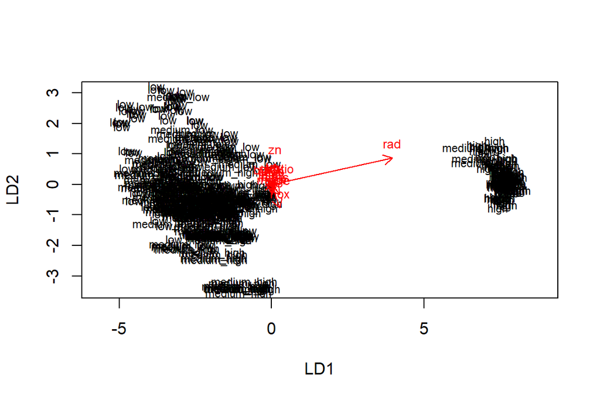

```r
# Plot the LDA
lda.arrows <- function(x, myscale = 1, arrow_heads = 0.1, color = "red", tex = 0.75, choices = c(1,2)){
  heads <- coef(x)
  graphics::arrows(x0 = 0, y0 = 0,
         x1 = myscale * heads[,choices[1]],
         y1 = myscale * heads[,choices[2]], col=color, length = arrow_heads)
  text(myscale * heads[,choices], labels = row.names(heads),
       cex = tex, col=color, pos=3)
}
classes <- as.numeric(train$crime)

plot(lda_fit, dimen = 2)
lda.arrows(lda_fit, myscale = 1)
```

From the plot it can be seen that the variable `rad` has a high impact on the crime rate, meaning that how closely located a suburb is to circular highways seems to be a variable with the most explanatory power on crime rates in the data.